# Project 3: Annual Average Daily Traffic, CA, 2012 by Susan S.

# Univariate Plots Section

```
Dimensions of dataset:  6768, 17
```

Column names:

```
##  [1] "dist"            "route"           "route_suffix"
##  [4] "county"          "postmile_prefix" "postmile"
##  [7] "alignment"       "description"     "back_peak_hour"
## [10] "back_peak_month" "back_aadt"       "ahead_peak_hour"
## [13] "ahead_peak_aadt" "ahead_aadt"      "county_name"
## [16] "district"        "county_pop"
```

Structure of dataset:

```
## 'data.frame':    6768 obs. of  17 variables:
##  $ dist           : Factor w/ 12 levels "1","2","3","4",..: 12 12 12 12 12 12 12 12 12 12 ...
##  $ route          : Factor w/ 243 levels "1","2","3","4",..: 1 1 1 1 1 1 1 1 1 1 ...
##  $ route_suffix   : Factor w/ 3 levels "","S","U": 1 1 1 1 1 1 1 1 1 1 ...
##  $ county         : chr  "ORA" "ORA" "ORA" "ORA" ...
##  $ postmile_prefix: Factor w/ 8 levels "","C","D","L",..: 6 6 1 1 1 1 6 6 1 1 ...
##  $ postmile       : num  0.129 0.78 8.43 9.418 9.6 ...
##  $ alignment      : Factor w/ 3 levels "","L","R": 1 1 1 1 1 1 1 1 1 1 ...
##  $ description    : Factor w/ 5762 levels ""," JCT. RTE. 101",..: 1129 1128 2623 2622 2619 2625 3508 3509 3510 3507 ...
##  $ back_peak_hour : int  NA 3750 2850 3000 3350 3150 4000 4250 4350 5400 ...
##  $ back_peak_month: int  NA 40000 38500 40500 39500 37500 49500 53000 53000 52000 ...
##  $ back_aadt      : int  NA 37000 36000 38000 37000 35000 45000 48000 48700 48500 ...
##  $ ahead_peak_hour: int  3750 3900 2850 3400 3350 3150 4800 4250 5300 5400 ...
##  $ ahead_peak_aadt: int  40000 42000 38500 40500 39500 38500 59000 53000 52000 52000 ...
##  $ ahead_aadt     : int  37000 38500 36000 38000 37000 35000 54000 48000 48700 48500 ...
##  $ county_name    : chr  "Orange" "Orange" "Orange" "Orange" ...
##  $ district       : int  12 12 12 12 12 12 12 12 12 12 ...
##  $ county_pop     : int  3073540 3073540 3073540 3073540 3073540 3073540 3073540 3073540 3073540 3073540 ...
```

Summary of dataset:

```
##       dist          route      route_suffix    county
##  4      :1084   101    : 507    :6738       Length:6768
##  7      : 913   5      : 420   S:  20       Class :character
##  3      : 771   1      : 278   U:  10       Mode  :character
##  6      : 721   99     : 254
##  11     : 609   80     : 157
##  8      : 581   10     : 152
##  (Other):2089   (Other):5000
##  postmile_prefix    postmile       alignment
##         :4695    Min.   :  0.000    :6649
##  R      :1844    1st Qu.:  5.752   L:  54
##  M      :  71    Median : 15.367   R:  65
##  T      :  70    Mean   : 22.308
##  L      :  63    3rd Qu.: 30.408
##  S      :  16    Max.   :186.238
##  (Other):   9    NA's   :6
##                                  description   back_peak_hour
##  JCT. RTE. 5                           :  33   Min.   :   10
##  JCT. RTE. 101                         :  16   1st Qu.:  940
##  JCT. RTE. 99                          :  14   Median : 2600
##  NEVADA STATE LINE                     :  13   Mean   : 5326
##  JCT. RTE. 15                          :  12   3rd Qu.: 8800
##  LOS ANGELES/SAN BERNARDINO COUNTY LINE:  12   Max.   :31000
##  (Other)                               :6668   NA's   :537
##  back_peak_month    back_aadt      ahead_peak_hour ahead_peak_aadt
##  Min.   :   100   Min.   :    80   Min.   :   10   Min.   :   100
##  1st Qu.:  9400   1st Qu.:  8200   1st Qu.:  940   1st Qu.:  9500
##  Median : 29000   Median : 25600   Median : 2600   Median : 29000
##  Mean   : 68262   Mean   : 64726   Mean   : 5333   Mean   : 68318
##  3rd Qu.:109000   3rd Qu.:104000   3rd Qu.: 8800   3rd Qu.:109000
##  Max.   :406000   Max.   :377500   Max.   :31000   Max.   :406000
##  NA's   :537      NA's   :537      NA's   :537     NA's   :537
##    ahead_aadt     county_name           district        county_pop
##  Min.   :    80   Length:6768        Min.   : 1.000   Min.   :   1114
##  1st Qu.:  8400   Class :character   1st Qu.: 4.000   1st Qu.: 182640
##  Median : 26000   Mode  :character   Median : 6.000   Median : 822403
##  Mean   : 64773                      Mean   : 6.134   Mean   :2000090
##  3rd Qu.:104000                      3rd Qu.: 8.000   3rd Qu.:2249045
##  Max.   :377500                      Max.   :12.000   Max.   :9946947
##  NA's   :537
```

I am not loading the CA traffic districts as a dataset, but am including the table here to help understand the plots by district. Traffic Districts http://en.wikipedia.org/wiki/California_Department_of_Transportation#Districts

| District | Counties |
| --- | --- |
| 1 | Del Norte, Humboldt, Lake, Mendocino Eureka |
| 2 | Lassen, Modoc, Plumas, Shasta, Siskiyou, Tehama, Trinity; portions of Butte and Sierra Redding |
| 3 | Butte, Colusa, El Dorado, Glenn, Nevada, Placer, Sacramento, Sierra, Sutter, Yolo,Yuba Marysville |
| 4 | Alameda, Contra Costa, Marin, Napa, San Francisco, San Mateo, Santa Clara, Solano, Sonoma, Oakland |
| 5 | Monterey, San Benito, San Luis Obispo, Santa Barbara, Santa Cruz San Luis Obispo |
| 6 | Madera, Fresno, Tulare, Kings, Kern Fresno |
| 7 | Los Angeles, Ventura Los Angeles |
| 8 | Riverside, San Bernardino San Bernardino |
| 9 | Inyo, Mono Bishop |
| 10 | Alpine, Amador, Calaveras, Mariposa, Merced, San Joaquin, Stanislaus, Tuolumne Stockton |
| 11 | Imperial, San Diego San Diego |
| 12 | Orange Irvine |

Frequency of District traffic counts:

```
##
##    1    2    3    4    5    6    7    8    9   10   11   12
##  325  411  771 1084  460  721  913  581   98  533  609  262
```

```
Sorted highest to lowest number of traffic counts
1084, 913, 771, 721, 609, 581, 533, 460, 411, 325, 262, 98
```

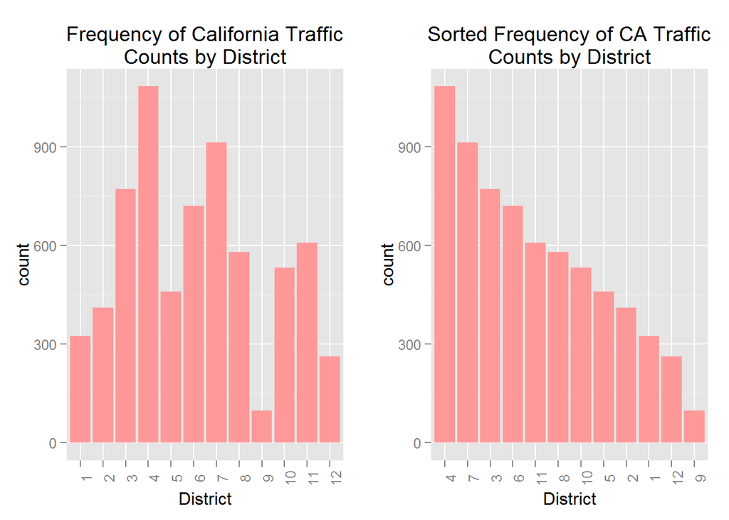

You can see from sorted traffic counts per district that district 4, which contains the San Francisco bay area, has the highest number of traffic counts. The lowest is district 9, which has the counties of Inyo, Mono, and Bishop

Look at the traffic counts on the different routes. As there are 243 routes, I am only listing the 20 with the most traffic counts and the 20 with the least traffic counts.

```
##
## 101   5   1  99  80  10  15  49  33  20 405  12 210   8 580  78  91 395
## 507 420 278 254 157 152 130 122  92  77  74  73  72  70  70  69  68  67
##  50   4
##  66  65
```

```
##
## 109 114 136 144 167 195 197 207 219 229 253 265 270 283 284 330  77 153
##   2   2   2   2   2   2   2   2   2   2   2   2   2   2   2   2   3   3
## 161 172
##   3   3
```

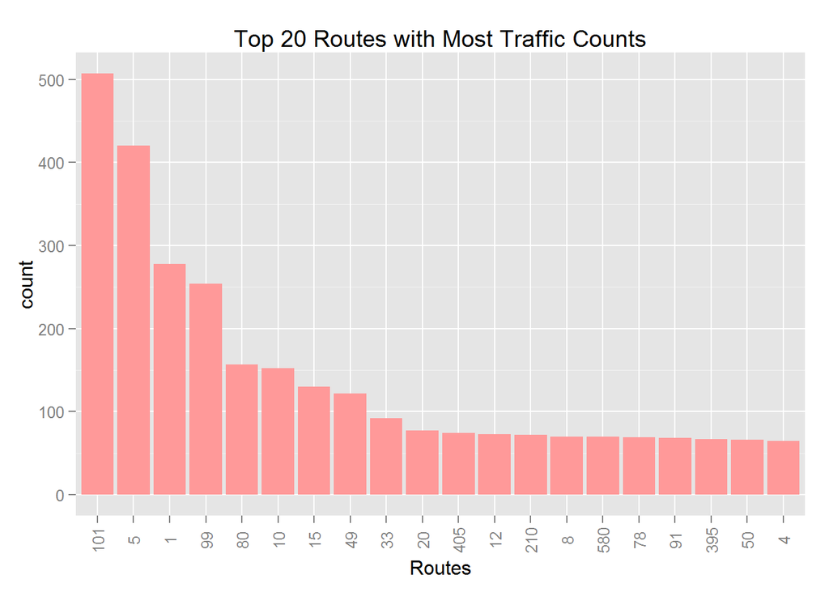

**Route Suffix:** A few routes or sections of routes are considered unrelinquished - a new alignment has been built, or the legislative definition has changed to omit the section, but the state still maintains the roadway - and are officially Route XU. State Route 14U, an old alignment of State Route 14, is the only one signed as such. Some new alignments are considered supplemental[5] and have a suffix of S. http://en.wikipedia.org/wiki/State_highways_in_California The route suffix column in the table is sparsely populated

```
## Source: local data frame [3 x 3]
##
##   route_suffix    n          description
## 1              6738         Normal Route
## 2            S   20   Supplemental Route
## 3            U   10 Unrelinquished Route
```

How many traffic counts in each county, and plots of the top and bottom 20:

```
##
##         Alameda          Alpine          Amador           Butte
##             220              19              47              96
##       Calaveras          Colusa    Contra Costa       Del Norte
##              50              36             109              36
##       El Dorado          Fresno           Glenn        Humboldt
##              80             183              42             146
##        Imperial            Inyo            Kern           Kings
##             156              45             267              49
##            Lake          Lassen     Los Angeles          Madera
##              45              41             762              56
##           Marin        Mariposa       Mendocino          Merced
##              60              31              98             103
##           Modoc            Mono        Monterey            Napa
##              22              53             111              59
##          Nevada          Orange          Placer          Plumas
##              68             261             103              44
##       Riverside      Sacramento      San Benito  San Bernardino
##             242             151              27             339
##       San Diego   San Francisco     San Joaquin San Luis Obispo
##             453              52             139             126
##       San Mateo   Santa Barbara     Santa Clara      Santa Cruz
##             157             128             202              70
##          Shasta          Sierra        Siskiyou          Solano
##             138              22              84              93
##          Sonoma      Stanislaus          Sutter          Tehama
##             132              91              40              54
##         Trinity          Tulare        Tuolumne         Ventura
##              28             163              54             152
##            Yolo            Yuba
##              89              44
```

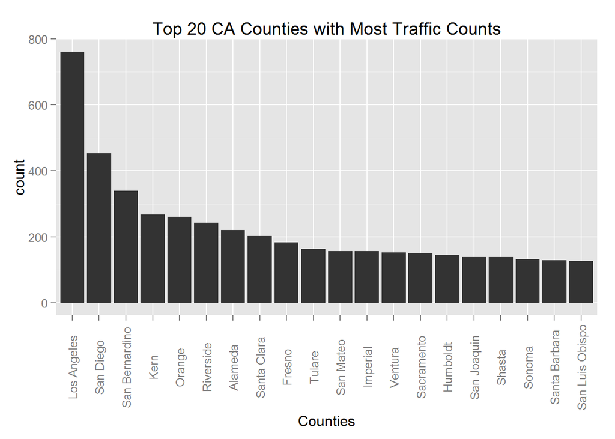

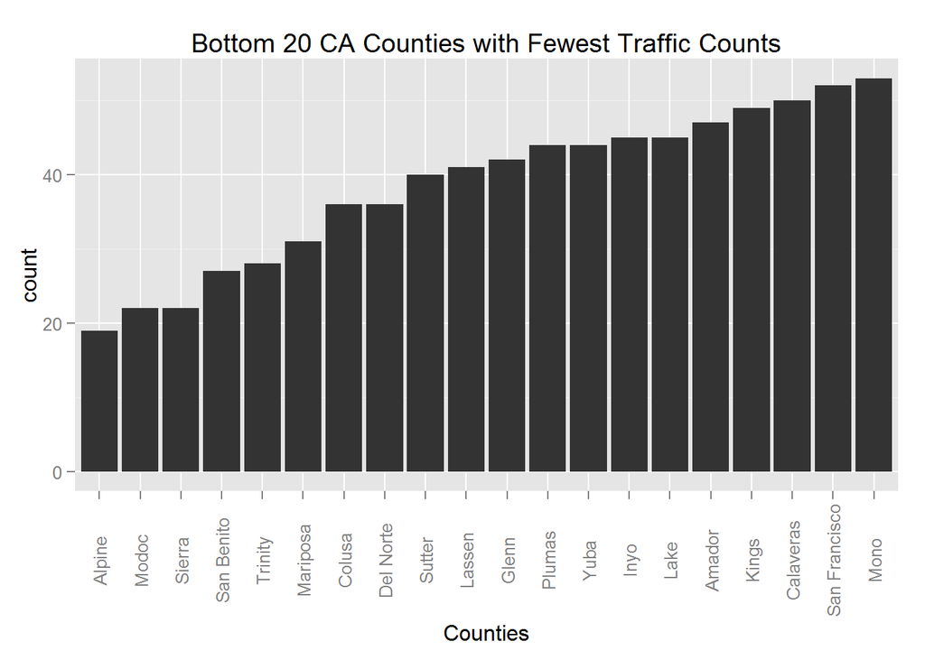

**Postmile and Postmile Prefix:** From http://www.dot.ca.gov/hq/tpp/offices/oasp/index_files/Overview_of_Postmile_System_GIS_Resources_EC_031513.pdf Postmile is the mile marker on the highway where the traffic measurement is done. Postmile values reset to zero at all county boundaries except when the route meanders between two counties or realignment, relinquishment or adoption at beginning of a route. Postmile increases on east and north sides of a route except for a few exceptions.

New postmile values are assigned whenever a length of highway is changed due to construction or realignment. To differentiate the new values from the old, an alpha code is added to the postmile as a prefix

Here are the counts of postmile prefix along with the definitions of them. Note that not all prefixes are in use.

```
## Source: local data frame [12 x 3]
##
##    postmile_prefix    n
## 1                  4695
## 2                C    6
## 3                D    3
## 4                L   63
## 5                M   71
## 6                R 1844
## 7                S   16
## 8                T   70
## 9                G   NA
## 10               H   NA
## 11               N   NA
## 12               U   NA
## Variables not shown: Meaning (fctr)
```

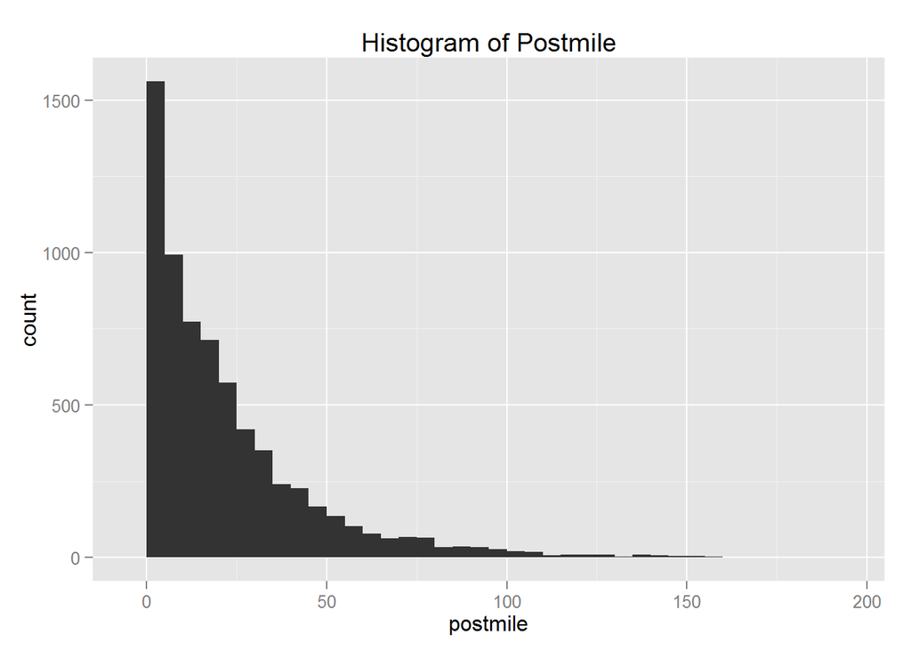

The highest postmile in a county is 186. They are concentrated in the lower mileage.

The alignment identifier is also called postmile suffix and identifies the independent alignment or unconstructed portion of highway. Most highway does not have an independent alignment.

**Alignment:**

```
## Source: local data frame [3 x 3]
##
##   alignment    n                 description
## 1           6649
## 2         L   54  Left independent alignment
## 3         R   65 Right independent alignment
```

### Traffic Counts

There are 6 different traffic count types in this dataset. Three are taken ahead (North or East of the location), and three are back (South or West of the location).  
* AADT is Annual Average Daily Traffic - total volume for the year divided by 365 days. It represents both directions of travel, so summing up would be erroneous.

- Peak Hour - estimate of heaviest traffic flow (usually rush hour).
- Peak Month ADT - average daily traffic for month of heaviest traffic flow - usually July or August, to take into account high seasonal volumes of traffic.

The hourly counts are smaller than the daily counts, as is obvious from the boxplot below.

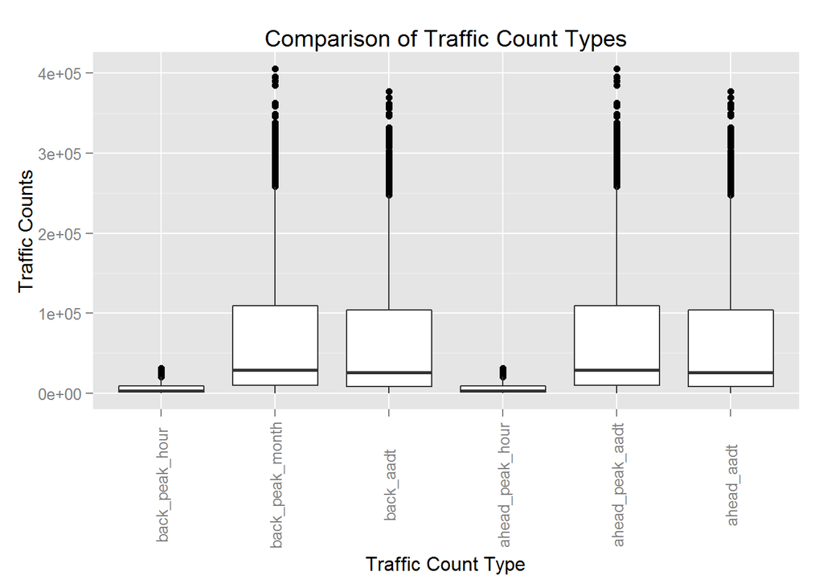

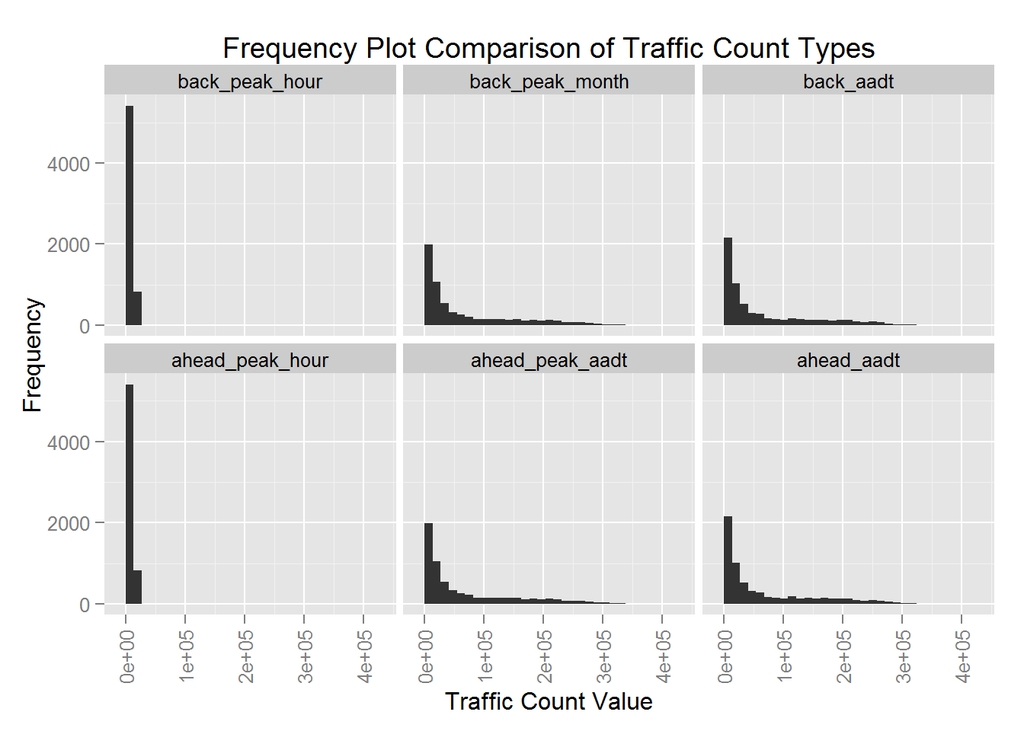

It is difficult to see the hourly and daily traffic counts in the same graph because the scales are so different. If I use free scales for the facets it might look better.

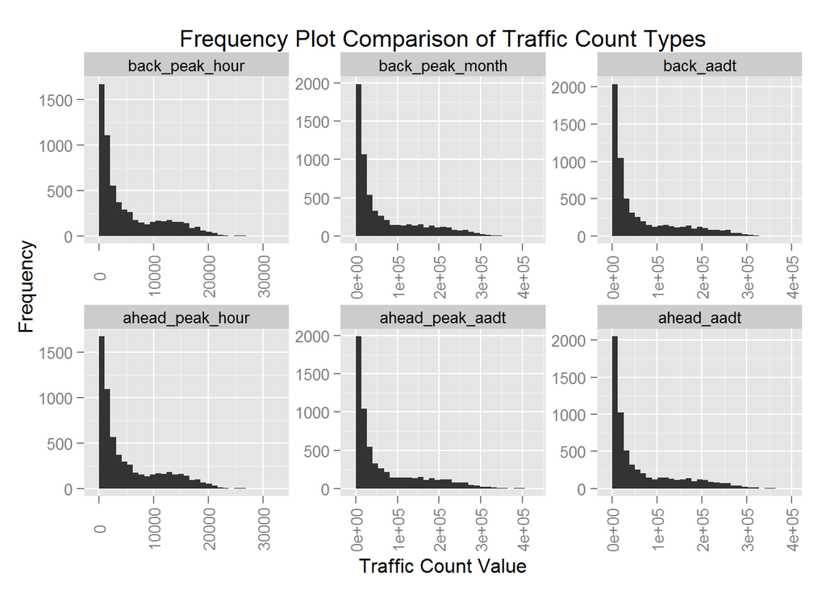

Hmm, I seem to remember seeing this type of distribution in one of the lessons and it was transformed into a normal distribution somehow… Lesson 3. By taking log. I will try to take the log or sqrt.

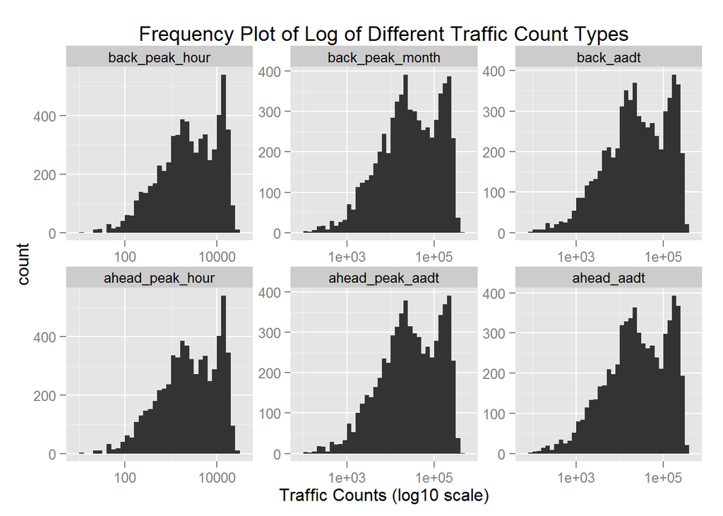

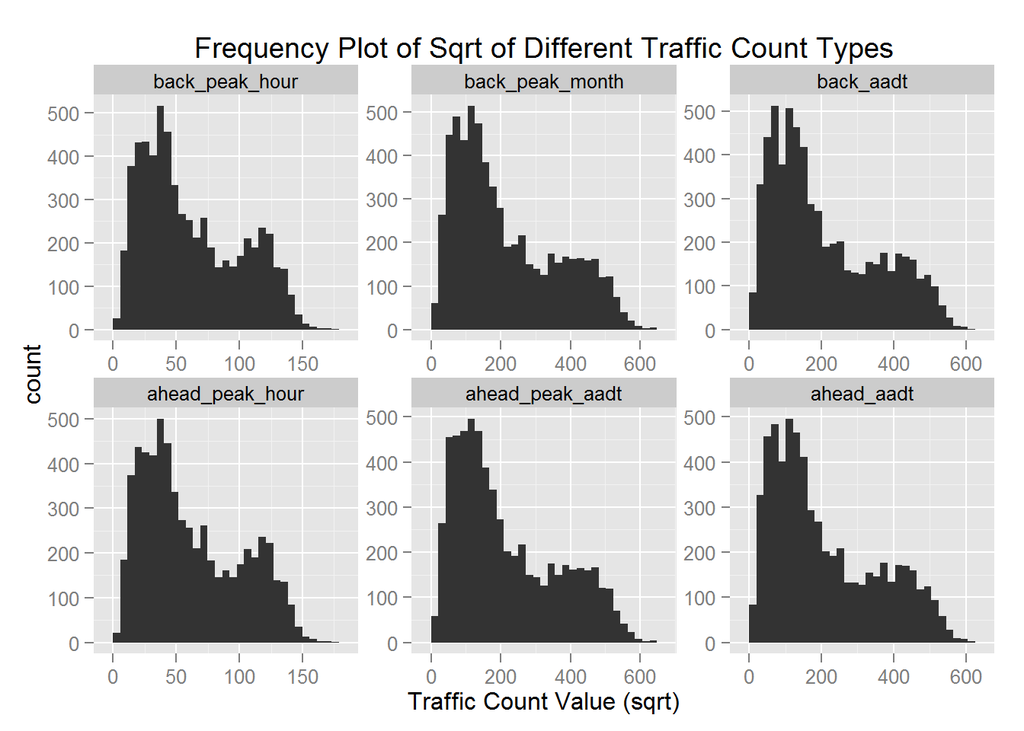

It looks like a bimodality - must be different types of highways Both transformations look more normal - log has no tail on right, sqrt has no tail on left  
Try to figure out why it is bimodal - add population to tidyData and cut it into two levels: county population under and over 1 Million people.

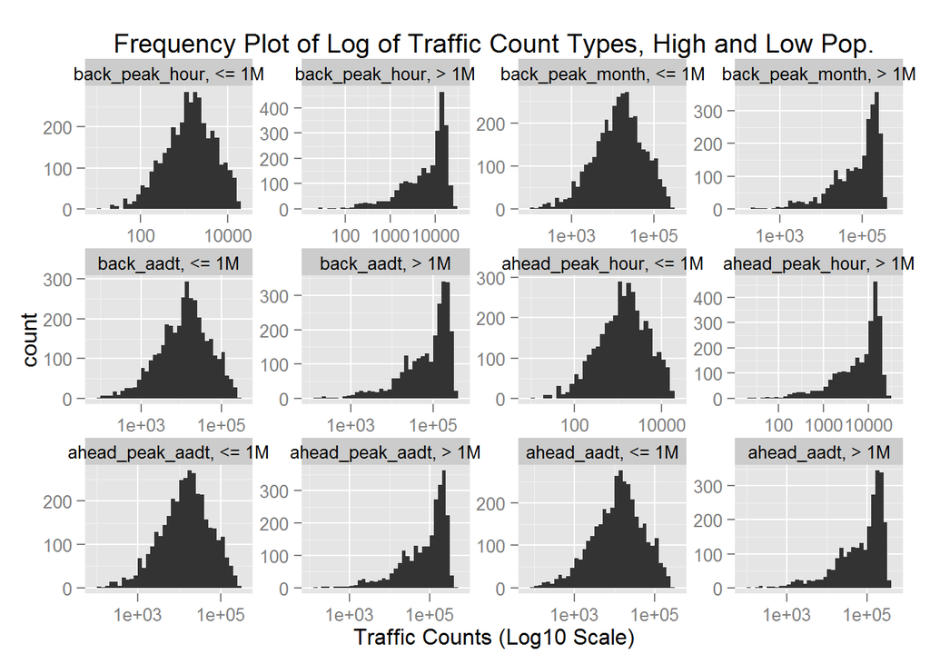

When I separate it out into counties that have under a Million population and over a Million Population, it separates the bimodality. Counties under a million have a more normally distributed traffic counts. Counties with over a million population have a higher skewed number of traffic count instances with high traffic counts.

OK, technically this should go into the bivariate section, but it started off trying to investigate the traffic counts on their own.

I wonder what these plots look like across the categorical variables of district, route, and county?

Now let’s look at the population by county (on July 1, 2012).

```
##             county pop20120701
## 1      Los Angeles     9946947
## 2        San Diego     3153376
## 3           Orange     3073540
## 4        Riverside     2249045
## 5   San Bernardino     2063867
## 6      Santa Clara     1827313
## 7          Alameda     1539145
## 8       Sacramento     1435118
## 9     Contra Costa     1069158
## 10          Fresno      948453
## 11            Kern      855974
## 12         Ventura      833361
## 13   San Francisco      822403
## 14       San Mateo      736019
```

[output cut: 44 more lines]

```
## 'data.frame':    58 obs. of  2 variables:
##  $ county     : chr  "Alameda" "Alpine" "Amador" "Butte" ...
##  $ pop20120701: int  1539145 1114 36403 220980 44923 21442 1069158 28533 182640 948453 ...
```

```
##     county           pop20120701
##  Length:58          Min.   :   1114
##  Class :character   1st Qu.:  47401
##  Mode  :character   Median : 180521
##                     Mean   : 652888
##                     3rd Qu.: 654100
##                     Max.   :9946947
```

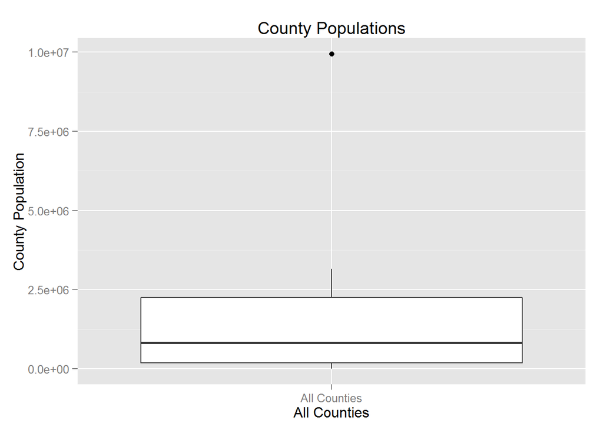

The high population of Los Angeles county distorts the mean.  
Look at population frequency and then remove the Los Angeles outlier.

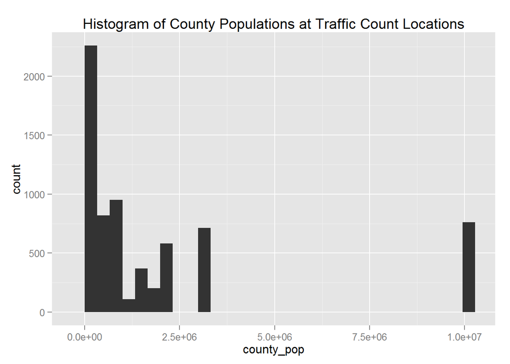

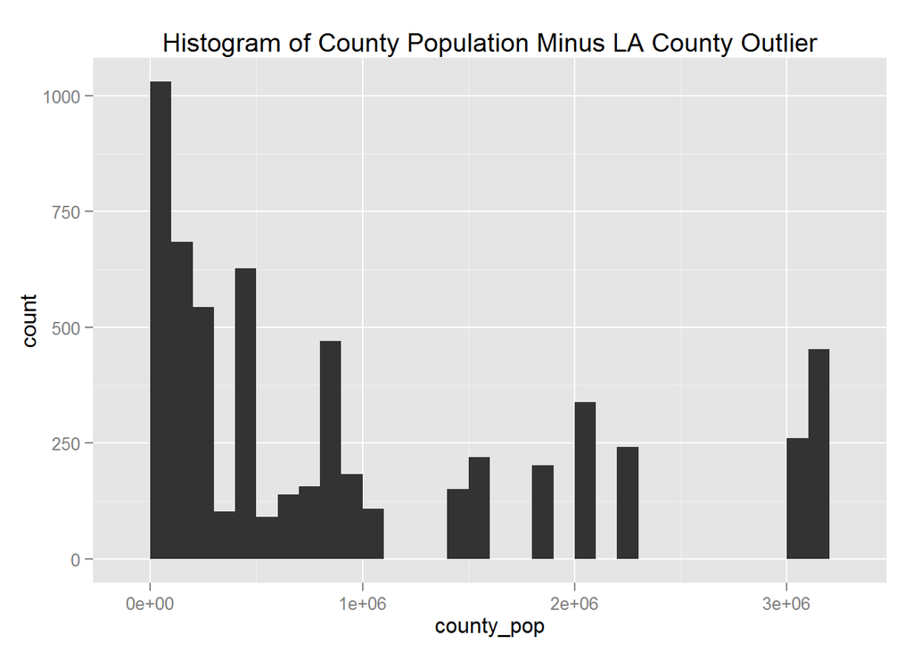

When I get rid of Lost Angeles, the population distribution is more even. The counties with smaller population might have fewer traffic counts, but there are a lot of them.

Plot county population, by county not by frequency in the dataset:

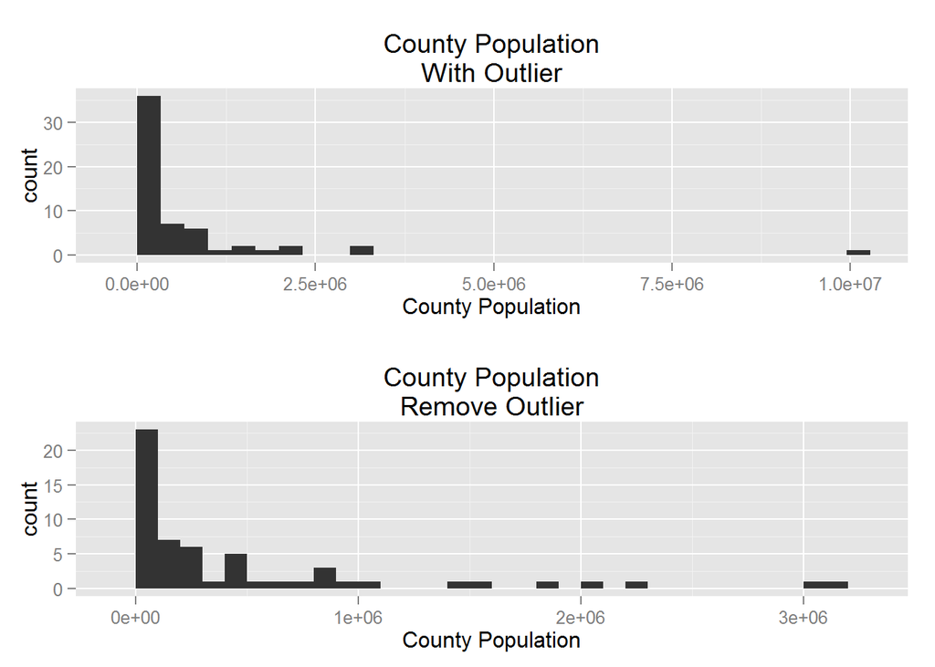

```r
q1 <- qplot(data=pop12, x = pop20120701, binwidth = max(pop12$pop20120701)/30) +
  ggtitle("County Population\nWith Outlier") + xlab("County Population")
q2 <- qplot(data=subset(pop12, pop20120701 < 5000000), x = pop20120701,
            binwidth = 100000)  + xlab("County Population") +
  ggtitle("County Population\nRemove Outlier")
grid.arrange(q1, q2, nrow=2)
```

Los Angeles has a very high population, so it is an outlier and makes it more difficult to see the population distribution in the lower counties. Removing counties with populations > 5 Million (Los Angeles) helps make the rest clearer. There are still a lot of counties with population under 100,000.

# Univariate Analysis

### What is the structure of your dataset?

There are 6768 traffic count locations in this dataset, with 8 original features: dist, route, route_suffix, county, postmile_prefix, postmile, alignment, description and 6 traffic count types: back_peak_hour, back_peak_month, back_aadt, ahead_peak_hour, ahead_peak_aadt, ahead_aadt plus county_name and county_pop (population)

There are 12 districts, 243 routes, 3 route suffixes (most are blank), 58 counties, 8 postmile prefixes (R is the most common besides blank), 3 alignments (most are blank), 5762 descriptions (which are the intersections with town or county/state line), and 537 missing traffic counts for each traffic type (at a boundary, the ahead and back counts are usually on separate lines).

Other observations:  
The most popular description is “JCT. RTE. 5”. The county with the most traffic count locations is Los Angeles. The district with the most traffic counts is 4, which includes San Francisco and Oakland. The route with the most traffic counts is 101. The ahead_peak_aadt was equal to or higher than the back_peak_month for min/mean/median/max. (these are equivalent measures at front and back of intersection, just not consistently named in source document)

It seems that the route with the largest number of traffic counts is State Highway 101, which covers California from South to North. There are 507 points on highway 101. It might be an interesting roadway to investigate.

The second most counted roadway is I-5. It is an interstate, not a state highway and it also covers the whole state from South to North.

The third most counted highway is highway 1, which hugs the coastline. The fourth is Highway 99. Those 4 have many more counts than the other highways.

Los Angeles has a huge population, which raises the mean much higher than the median county population.

All of the traffic count types have a high concentration of counts that are in the lower 2/30 of the traffic count range. The hourly traffic counts have a slightly different distribution than the daily traffic counts - the daily counts had more falling into the lower 1/30 than the hourly counts.

### What is/are the main feature(s) of interest in your dataset?

The main features of interest are the traffic counts, counties and routes.  
I also added population from a separate table to do traffic correlation based on county population.

### What other features in the dataset do you think will help support your investigation into your feature(s) of interest?

The routes help me break the data set down into something I can look at. The population count also has the population difference between 2012 and 2013 which could be useful to see if people came to or left areas of high traffic. But I will not have time to investigate that.

### Did you create any new variables from existing variables in the dataset?

I created a county_name variable which was the full name of the county taken from the county in the dataset which was actually an abbreviation.

In a subset of data for Highway 101 I created a cumulative mileage column. In the next sections I created a few summary datasets such as dfp3.bpm_by_county and dfp3.baadt_by_county to plot the mean traffic by county and do modeling to predict average traffic based on population.

### Of the features you investigated, were there any unusual distributions? Did you perform any operations on the data to tidy, adjust, or change the form of the data? If so, why did you do this?

I created a tidy data set of one variable/value pair per row so that I could plot the different traffic types in a facet.

I looked at the traffic distributions and saw that a log transformation would make them more normal, so I plotted the log10 of the traffic counts. It looked bimodal. I separated it by county population - made two groups using cut: one for counties with population under a million and the rest over a million.  
This removed the bimodality. Counties with under a million residents had a more normal-looking log traffic frequency distribution.

I summarized the traffic (back peak month) by county_name since I had the population of the counties, so I could compare the average traffic to the county population. I tried to find a correlation, so I plotted each axis as a log function until I found one that looked correlated - the log of the county population is correlated with the log of the average traffic (back peak month).

To look at the county population distribution, I removed Los Angeles because it was such an outlier (population of over 9 million when next largest county only had 3 million). It made the histogram spread out more.

# Bivariate Plots Section

Below is a correlation matrix of the numeric columns in my main data frame.

```
##                 ahead_peak_hour ahead_peak_aadt ahead_aadt back_peak_hour
## ahead_peak_hour       1.0000000       0.9861205  0.9851281      0.9784667
## ahead_peak_aadt       0.9861205       1.0000000  0.9992771      0.9689689
## ahead_aadt            0.9851281       0.9992771  1.0000000      0.9680152
## back_peak_hour        0.9784667       0.9689689  0.9680152      1.0000000
## back_peak_month       0.9679986       0.9831139  0.9826660      0.9862641
## back_aadt             0.9672250       0.9827562  0.9833376      0.9852505
## county_pop            0.5019581       0.5268439  0.5305682      0.5020283
## postmile             -0.1127205      -0.1189987 -0.1234395     -0.1535695
##                 back_peak_month  back_aadt  county_pop    postmile
## ahead_peak_hour       0.9679986  0.9672250  0.50195813 -0.11272049
## ahead_peak_aadt       0.9831139  0.9827562  0.52684388 -0.11899871
## ahead_aadt            0.9826660  0.9833376  0.53056818 -0.12343946
## back_peak_hour        0.9862641  0.9852505  0.50202832 -0.15356953
## back_peak_month       1.0000000  0.9993272  0.52685191 -0.15792589
## back_aadt             0.9993272  1.0000000  0.53044740 -0.16222574
## county_pop            0.5268519  0.5304474  1.00000000 -0.03568948
## postmile             -0.1579259 -0.1622257 -0.03568948  1.00000000
```

The traffic counts are all well correlated. The traffic is somewhat correlated with county population (around .5) - it is expected that more people lead to more cars and to more traffic even if there are other factors such as availability of public transportation that also affect traffic. One surprising finding is that the postmile (distance from S or W end of route in county) is slightly negatively correlated with traffic and even more slightly negatively correlated with county population. There is slightly more traffic at the start of the route (S or W end).

Look at traffic counts by district:

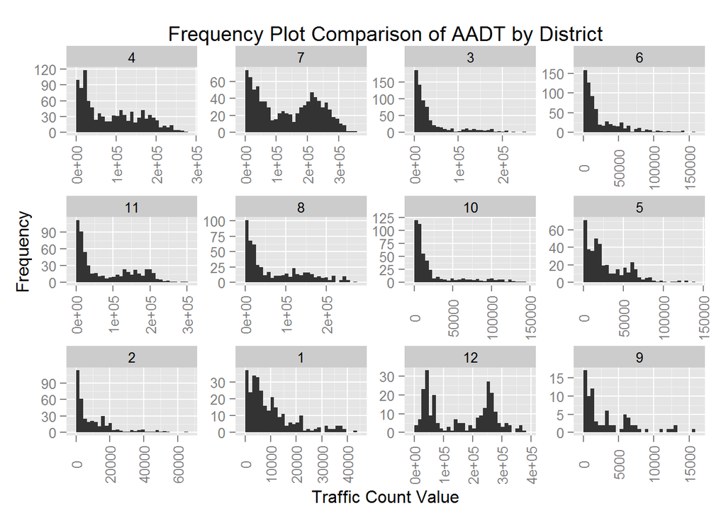

You can see here that not all districts have bimodal traffic distributions. Districts 1, 2, and 3 are all less built up and have mostly decreasing distributions. District 4 has a few peaks and is taller with a short tail. It contains the San Franciso/Silicon Valley area and has a spread out high traffic. District 7 contains Los Angeles and it has a large second peak where there is a lot of traffic. The last one with a big second peak is District 12, which contains Orange and Irvine counties. This district is unique in that it does not have many areas with low traffic. It has the highest traffic rates and a peak of roadway sites with traffic between 200 and 300 thousand cars a day. As a side note, I once had a tour of the Irvine traffic control center and it was pretty impressive!

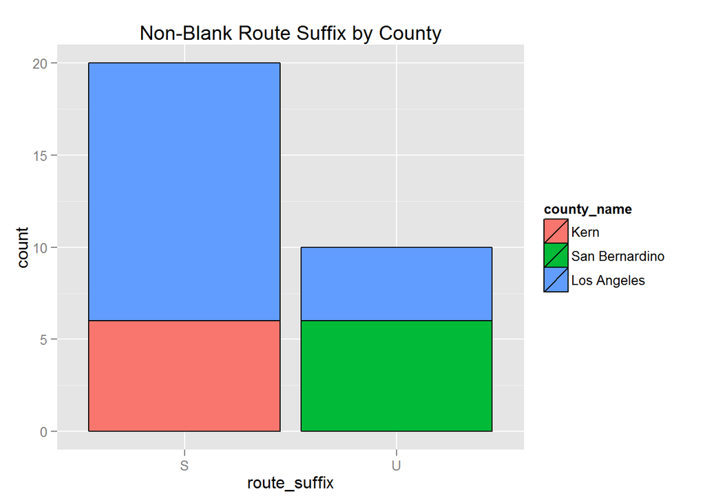

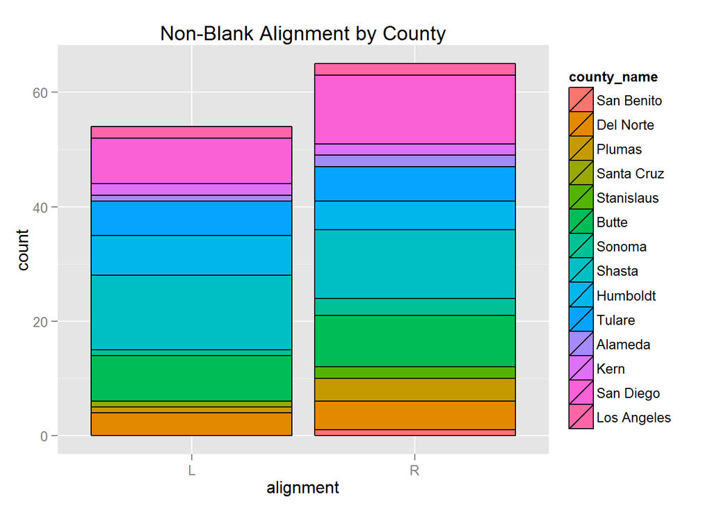

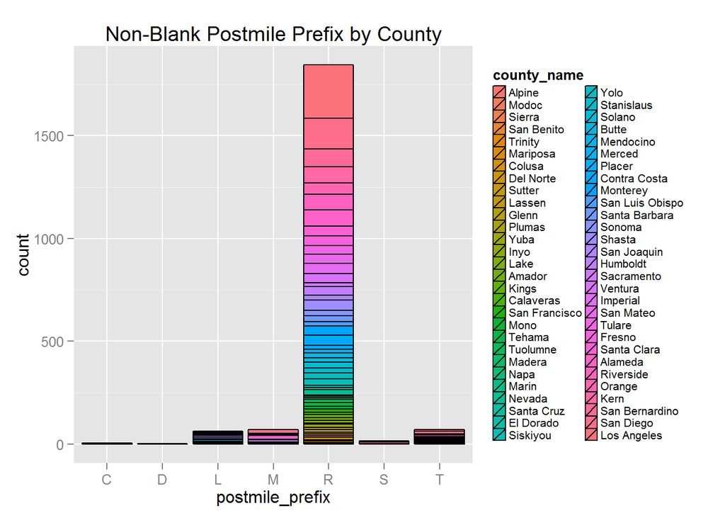

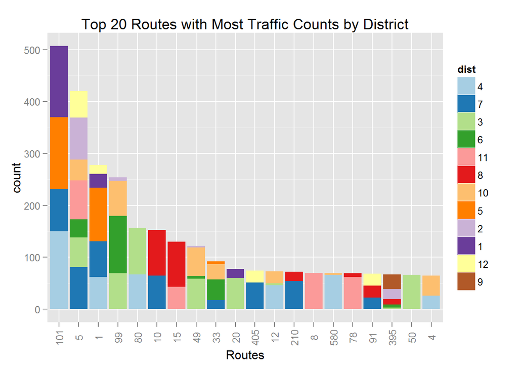

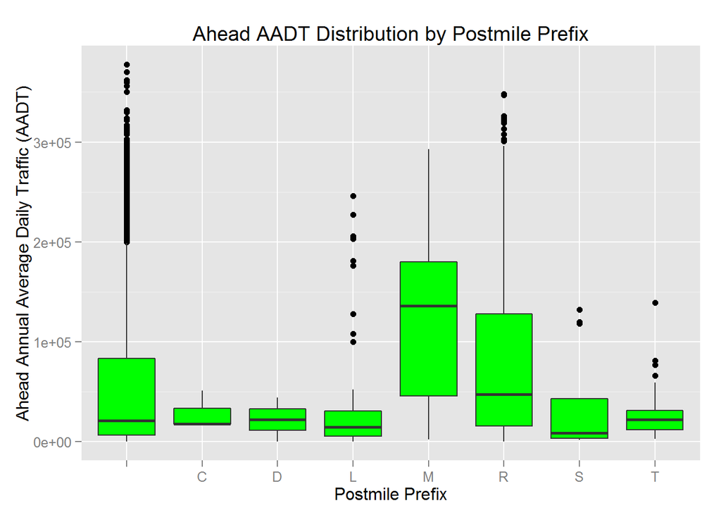

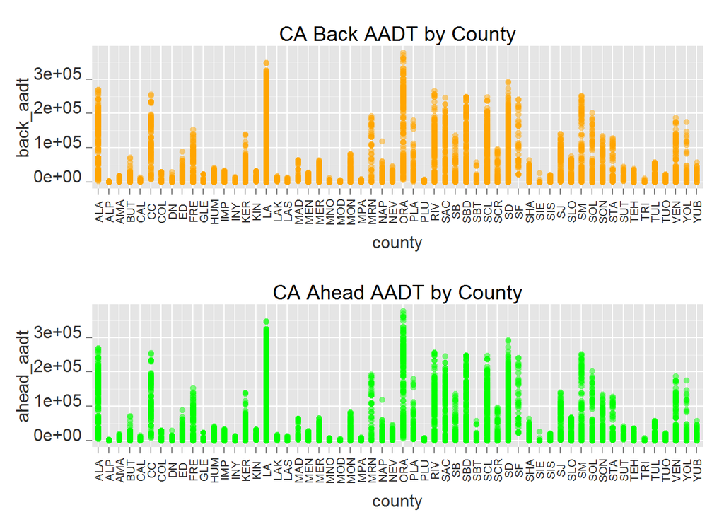

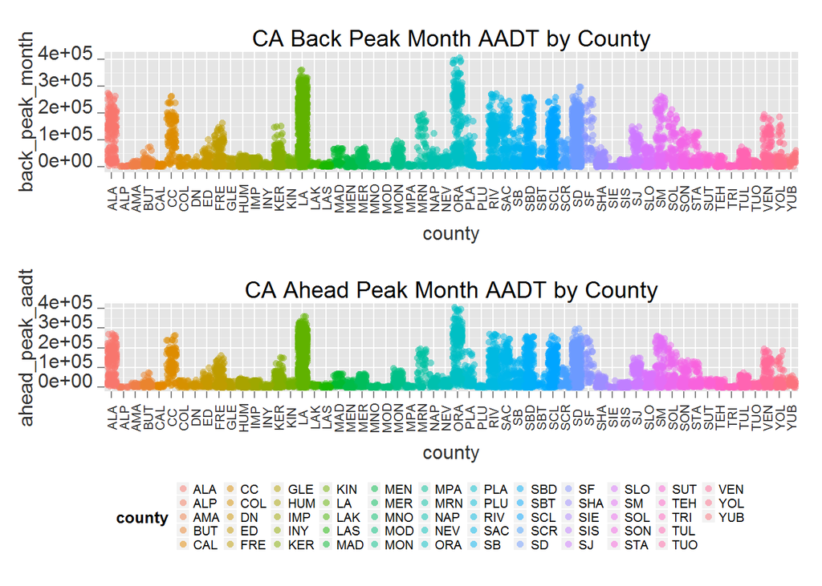

These were some of my first plots. They are not very easy to read although they are colorful! I hope I am not penalized for leaving them in. Orange County has the highest traffic, and then LA.

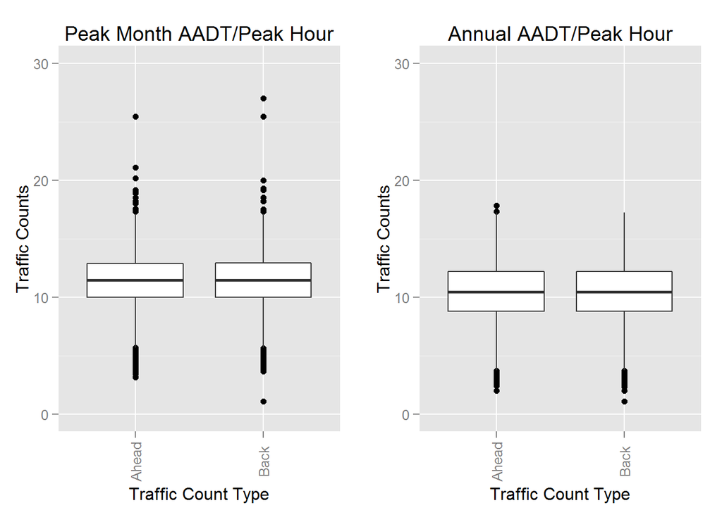

The statistics of the ratio of peak month AADT to peak hour AADT:

```r
# Peak month daily vs peak hourly
summary(dfp3$back_peak_month/dfp3$back_peak_hour)
```

```
##    Min. 1st Qu.  Median    Mean 3rd Qu.    Max.    NA's
##   1.095  10.000  11.460  11.430  12.910  27.000     537
```

```r
summary(dfp3$ahead_peak_aadt/dfp3$ahead_peak_hour)
```

```
##    Min. 1st Qu.  Median    Mean 3rd Qu.    Max.    NA's
##   3.167  10.000  11.440  11.430  12.890  25.470     537
```

```r
# Average daily vs peak hourly
summary(dfp3$back_aadt/dfp3$back_peak_hour)
```

```
##    Min. 1st Qu.  Median    Mean 3rd Qu.    Max.    NA's
##   1.063   8.800  10.430  10.390  12.190  17.220     537
```

```r
summary(dfp3$ahead_aadt/dfp3$ahead_peak_hour)
```

```
##    Min. 1st Qu.  Median    Mean 3rd Qu.    Max.    NA's
##   2.000   8.789  10.430  10.390  12.190  17.820     537
```

Look at population by county.

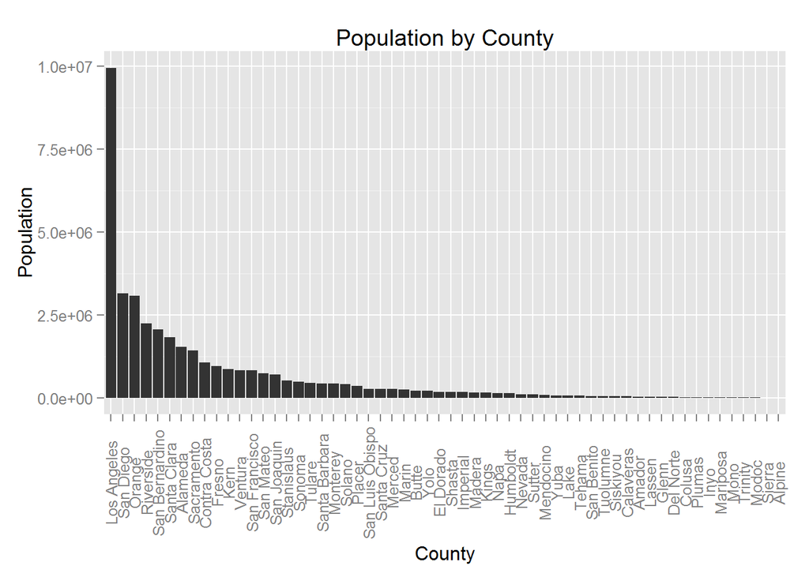

Los Angeles has such a high population that it skews results. Looking at a log10 distribution shows all better.

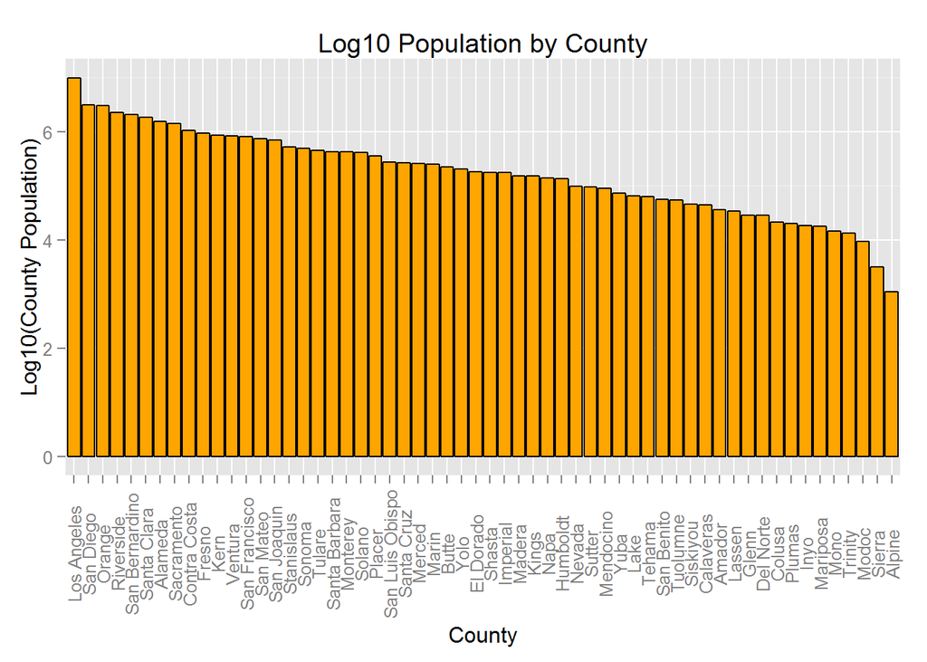

Traffic Counts by population - This won’t work very well in a bivariate plot because population is the same for all points in a county.

# Bivariate Analysis

### Talk about some of the relationships you observed in this part of the investigation. How did the feature(s) of interest vary with other features in the dataset?

Los Angeles county has a much larger population than all the other counties. The Peak month annual average daily traffic was an average of 11 times greater than the peak hourly average traffic. The average daily traffic was only 10 times greater.

### Did you observe any interesting relationships between the other features (not the main feature(s) of interest)?

Only three counties (Los Angeles, San Bernardino, and Kern had roads with route suffixes appended while fourteen counties had alignment changes and all fifty-eight had at least one postmile prefix (most frequently ‘R’).

I noticed in the plots that the postmile prefix ‘M’ had the highest mean AADT. ‘M’ is the realignment of ‘R’ mileage, where ‘R’ was the first realignment. So it seems like when a second realignment is needed for a roadway, it tends to have higher traffic than the first realignment (‘R’), which also tended to have higher traffic than non-realigned roadways.

The peak month daily traffic was an average of 11 times greater than the peak hourly traffic.

### What was the strongest relationship you found?

All of the traffic counts were correlated with each other, but that was to be expected. The strongest was back_aadt with back_peak_month - highest daily traffic correlating to highest daily traffic in the peak month. The ahead traffic correlation was almost as high. This means there weren’t big anomalies in the peak monthly traffic.

# Multivariate Plots Section

Looking at Traffic counts on the routes that go through Alameda county.

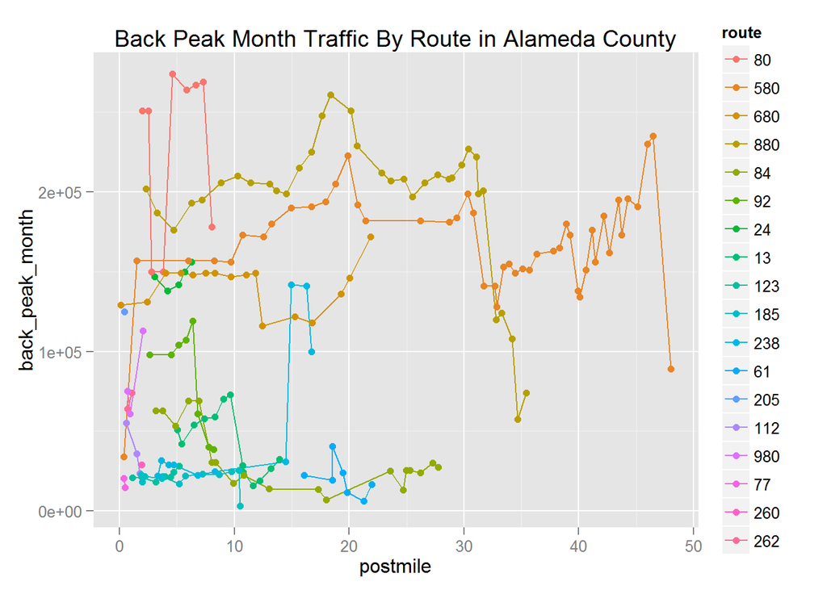

I-80 only has less than 10 miles of roadway in the county but it has some of the highest traffic. I-880 also has a lot of traffic at its beginning, but the traffic drops. This plot is a little busy and may not be optimal.

**Looking at Highway 101**  
Instead of focusing on a county, I will focus on a route. Highway 101 from South to North goes through these counties in order: (from http://en.wikipedia.org/wiki/U.S._Route_101_in_California)

```
LA  - Los Angeles
VEN - Ventura
SB  - Santa Barbara
SLO - San Luis Obispo
MON - Monterey
SBT - San Benito
SCL - Santa Clara
SM  - San Mateo
SF  - San Francisco
MRN - Marin
SON - Sonoma
MEN - Mendocino
HUM - Humboldt
DN  - Del Norte
```

Look at the traffic on Highway 101 throughout it’s length

Plotting traffic along Highway 101 with help from  
http://stackoverflow.com/questions/13616515/recommend-a-scale-colour-for-13-or-more-categories and  
http://stackoverflow.com/questions/17844494/change-grid-line-behavior-in-ggplot2

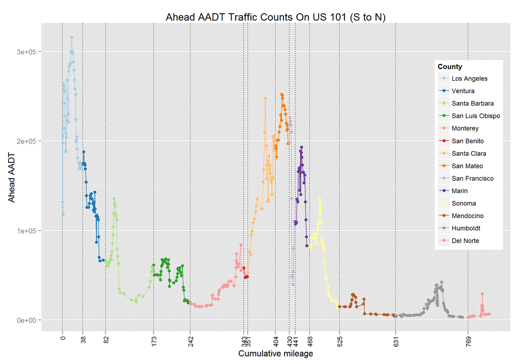

Adding in peak traffic (the triangles)…

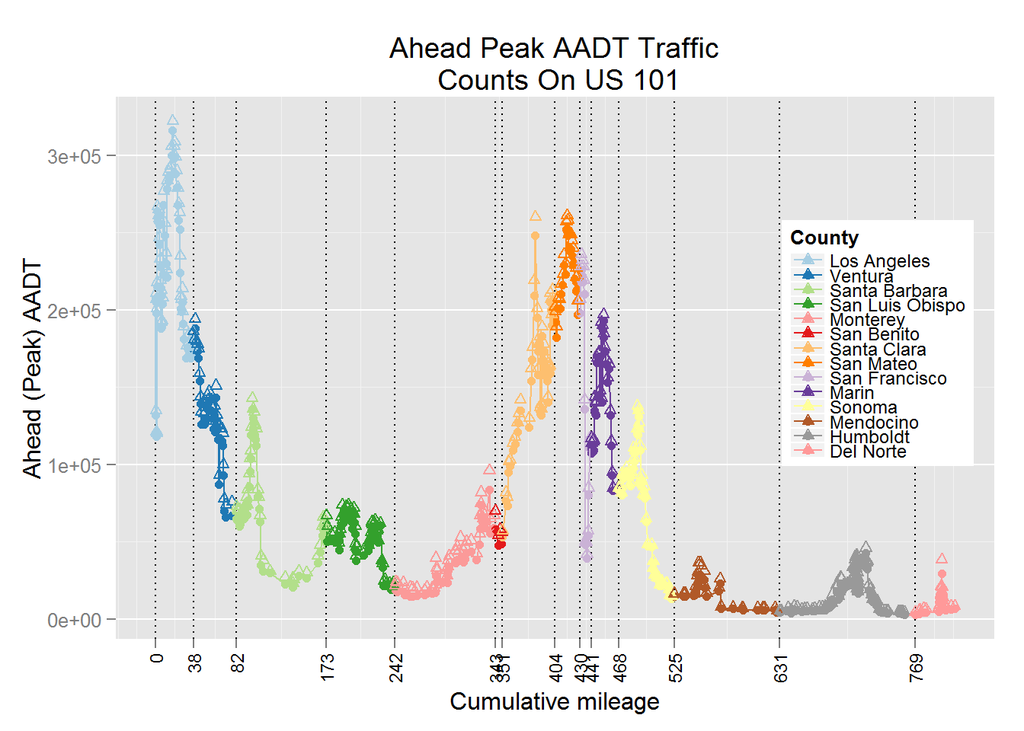

The triangles are peak month aadt - it looks like all of the peak traffic locations still have room for even more traffic at peak seasons! Adding the peak traffic makes the plot look a little busy.  
I will not use it for one of my final plots.

I created a separate dataset called hw101 that is a subset of the main dataset, but also has cumulative mileage. What are the column names in hw101 in the knitted dataset?

```
##  [1] "dist"            "route"           "route_suffix"
##  [4] "county"          "postmile_prefix" "postmile"
##  [7] "alignment"       "description"     "back_peak_hour"
## [10] "back_peak_month" "back_aadt"       "ahead_peak_hour"
## [13] "ahead_peak_aadt" "ahead_aadt"      "county_name"
## [16] "district"        "county_pop"      "county_postmile"
## [19] "cm101"           "cm"
```

```
## 'data.frame':    507 obs. of  20 variables:
##  $ dist           : Factor w/ 12 levels "1","2","3","4",..: 7 7 7 7 7 7 7 7 7 7 ...
##  $ route          : Factor w/ 243 levels "1","2","3","4",..: 90 90 90 90 90 90 90 90 90 90 ...
##  $ route_suffix   : Factor w/ 3 levels "","S","U": 1 1 1 1 1 1 1 1 1 1 ...
##  $ county         : Ord.factor w/ 14 levels "LA"<"VEN"<"SB"<..: 1 1 1 1 1 1 1 1 1 1 ...
##  $ postmile_prefix: Factor w/ 8 levels "","C","D","L",..: 7 7 7 7 1 1 1 1 1 1 ...
##  $ postmile       : num  0 0.624 0.907 1.329 0 ...
##  $ alignment      : Factor w/ 3 levels "","L","R": 1 1 1 1 1 1 1 1 1 1 ...
##  $ description    : Factor w/ 5762 levels ""," JCT. RTE. 101",..: 2902 2864 2861 2885 2885 2994 2814 2973 2889 2869 ...
##  $ back_peak_hour : int  NA 9000 7900 7700 NA 13800 13300 12700 13600 15800 ...
##  $ back_peak_month: int  NA 135000 121000 120000 NA 211000 207000 201000 218000 267000 ...
##  $ back_aadt      : int  NA 132000 120000 118000 NA 207000 205000 198000 215000 264000 ...
##  $ ahead_peak_hour: int  9000 7900 7700 NA 13800 13300 12700 13600 15800 15400 ...
##  $ ahead_peak_aadt: int  135000 121000 120000 NA 211000 207000 201000 218000 267000 261000 ...
##  $ ahead_aadt     : int  132000 120000 118000 NA 207000 205000 198000 215000 264000 257000 ...
##  $ county_name    : Ord.factor w/ 14 levels "Los Angeles"<..: 1 1 1 1 1 1 1 1 1 1 ...
##  $ district       : int  7 7 7 7 7 7 7 7 7 7 ...
##  $ county_pop     : int  9946947 9946947 9946947 9946947 9946947 9946947 9946947 9946947 9946947 9946947 ...
##  $ county_postmile: chr  "LA_S_0" "LA_S_0.624" "LA_S_0.907" "LA_S_1.329" ...
##  $ cm101          : num [1:507(1d)] 0 0 0 0 0 0 0 0 0 0 ...
##  $ cm             : num [1:507(1d)] 0 0.624 0.907 1.329 0 ...
```

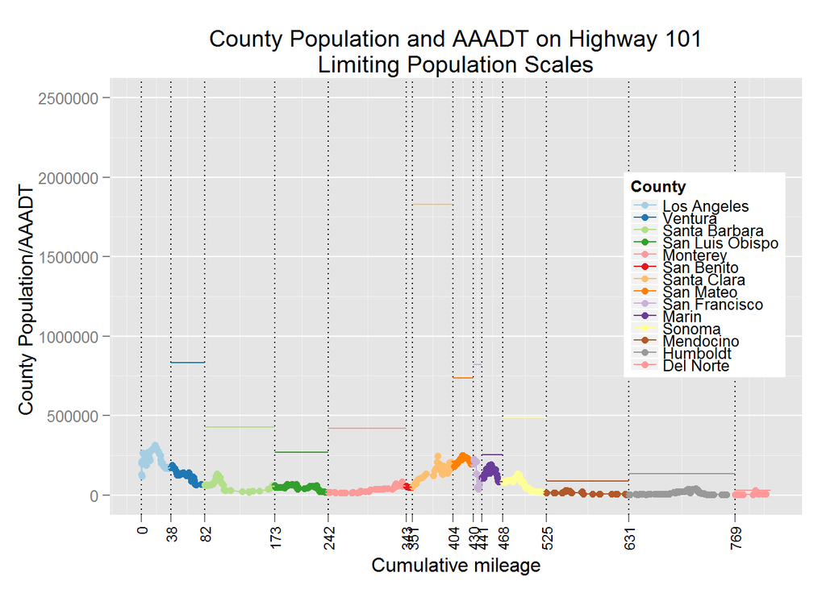

I tried to plot county population and Ahead Annual Average Daily Traffic (AAADT) along Highway 101 on the same plot to show how traffic could be related to population but I could not easily figure out how to get two scales on the same chart (which I used to do all the time in gnuplot with y1 and y2 axes). It seems that the R way is not to mix scales but instead to facet. If I had more time I would try to plot them together with a facet. I limited the y scale so some higher populations were left out. If I were using this graph I would have to foot note that.